# Untitled

Zjrobbin

4/6/2021

## Functional Groups

To fit the parameters around the functional group we compare the most prevalent species to the FIA record of biomass per site, and a published value for LAI. For each, we ran single-cell simulations using the mean landscape values for NECN inputs. Each stand was initialized with two cohorts (one age 0 and one age 10) both with densities of 1000 g/m2.

#### Northern Conifer

For northern conifers the most prevelent species was Pinus strobus.

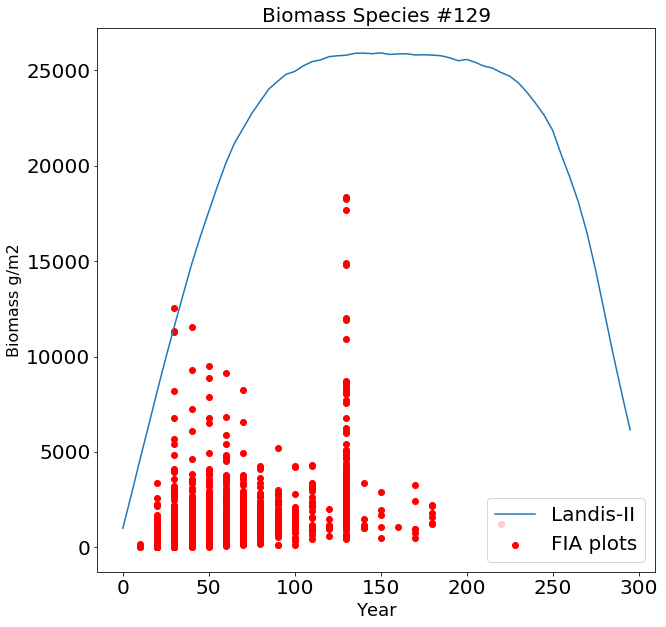

Northern Conifer Biomass

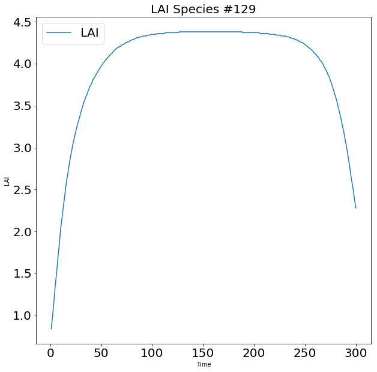

Compared to white/red/jack pine values from He, L., Chen, J. M., Pan, Y., Birdsey, R., & Kattge, J. (2012). Relationships between net primary productivity and forest stand age in US forests. Global Biogeochemical Cycles, 26(3).

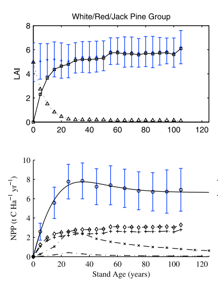

White Pine LAI

### Southern Conifer

For southern conifers we compared published values from Pinus Taeda

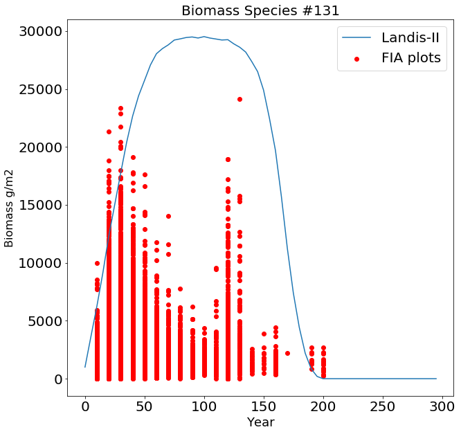

Pinus taeda Biomass

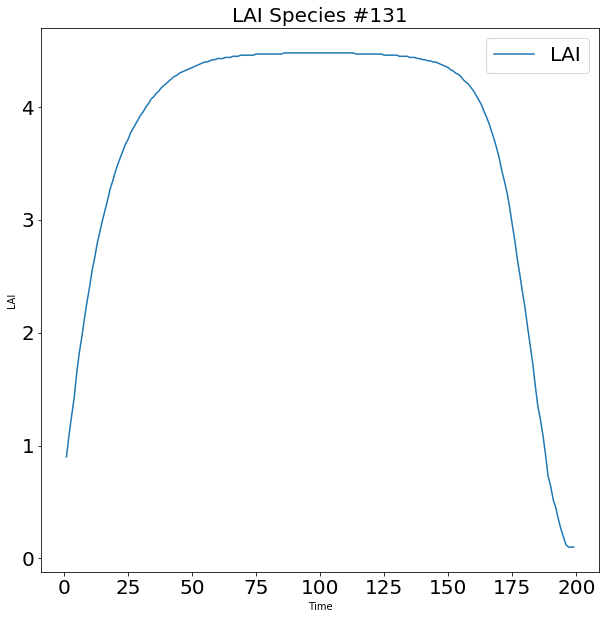

Here are values from Loblolly/shortleaf pine stands from He, L., Chen, J. M., Pan, Y., Birdsey, R., & Kattge, J. (2012). Relationships between net primary productivity and forest stand age in US forests. Global Biogeochemical Cycles, 26(3).

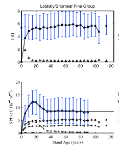

Lobolloy LAI

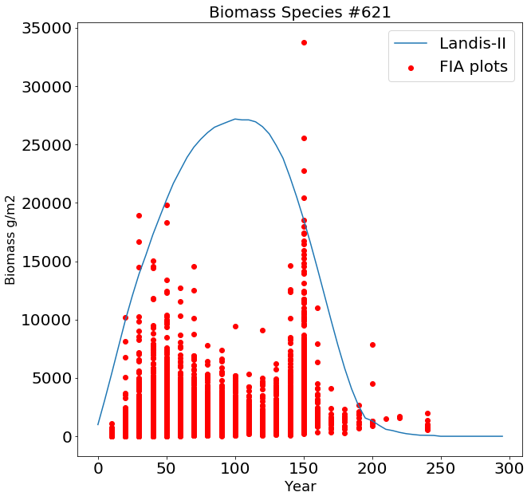

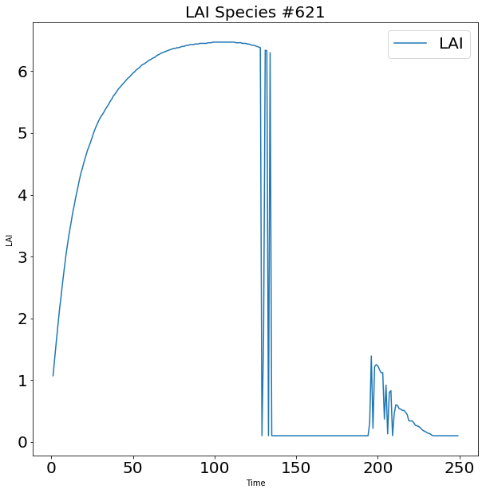

Published values from Mixed Tulip-poplar/ Sweet gum forests

Brown, M. J., & Parker, G. G. (1994). Canopy light transmittance in a chronosequence of mixed-species deciduous forests. Canadian Journal of Forest Research, 24(8), 1694-1703.

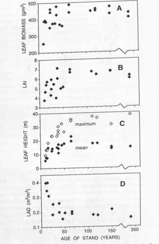

Tupli poplar LAI

### Northern Hardwoods

Chestnut oak (Quercus montana) was used to compare northern hardwoods

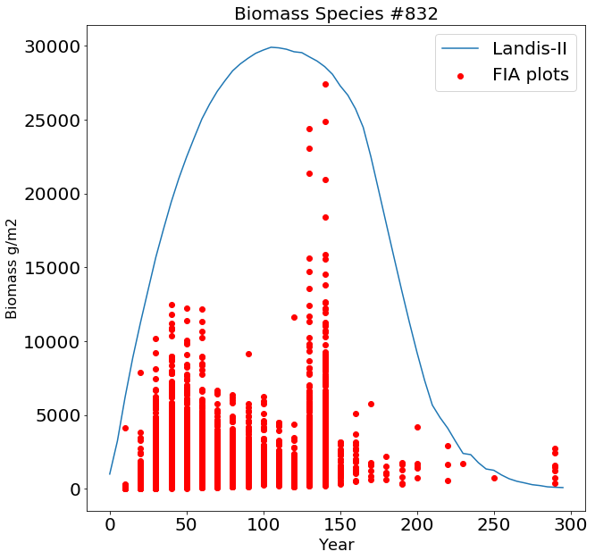

Chestnut Oak Biomass

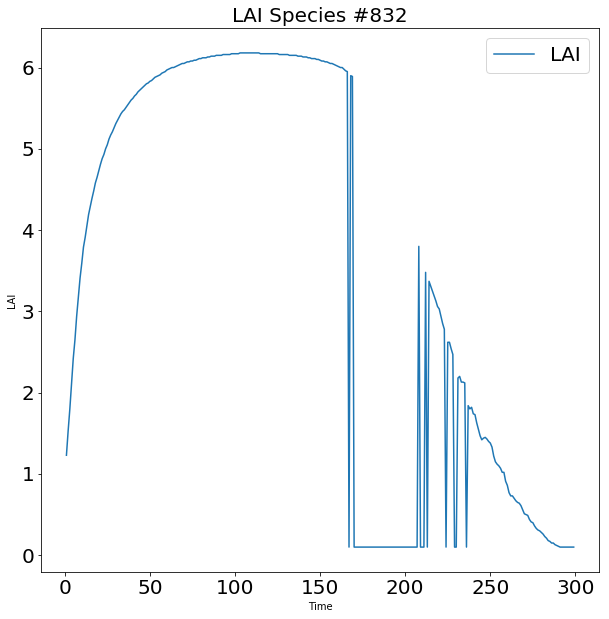

Published Chestnut Oak LAI He, L., Chen, J. M., Pan, Y., Birdsey, R., & Kattge, J. (2012). Relationships between net primary productivity and forest stand age in US forests. Global Biogeochemical Cycles, 26(3).

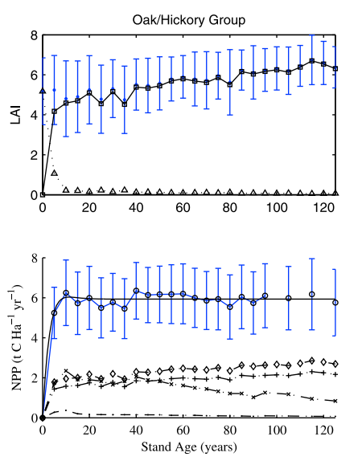

Chestnut Oak LAI

### Hemlock

Hemlock is its own functional group.

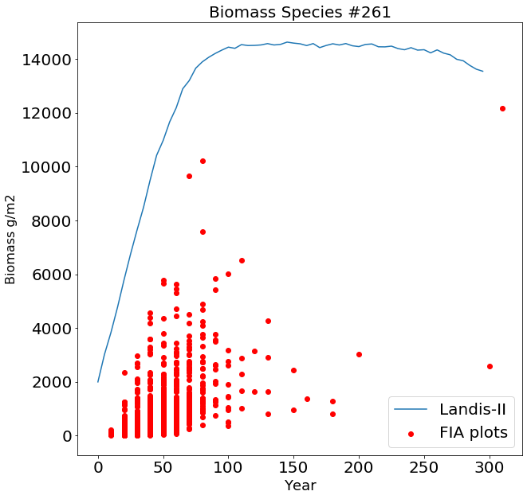

Hemlock Biomass

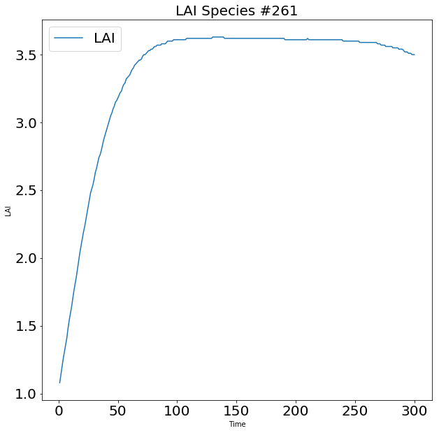

Hemlock LAI

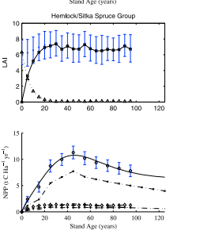

Hemlock LAI

### Swampy

For this functional group we used Betula Alleghaniensis

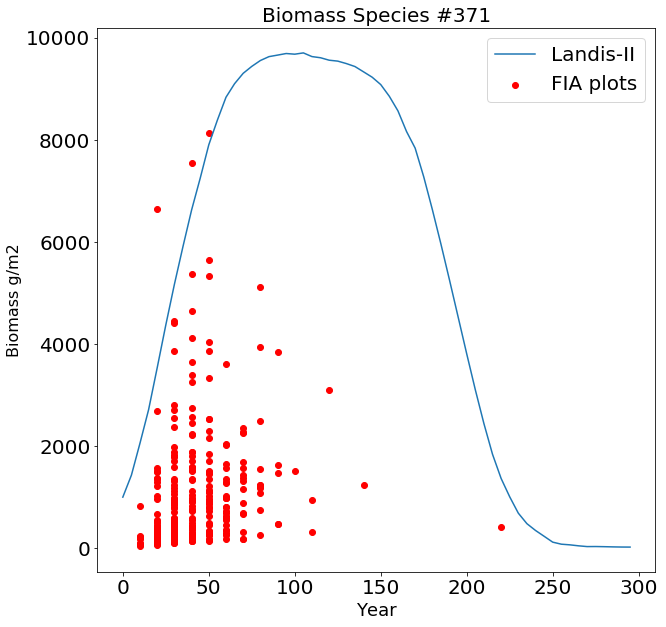

Yellow Birch

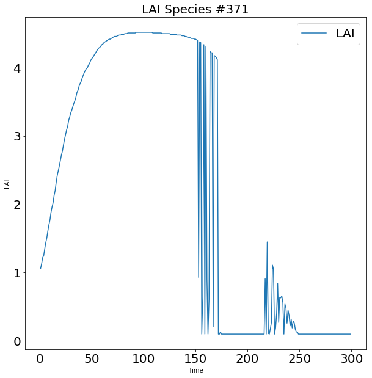

Yellow Birch

We compared this to Maple, Beech and Birch stands

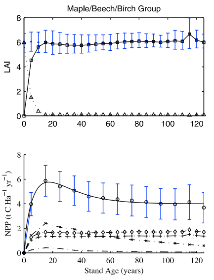

Beech LAI

### Abies

For this functional group we used Fraser Fir, unfortunately there were very few FIA plots to use as comparison, so we used the max biomass esablished in prior LANDIS-II studies of the species.

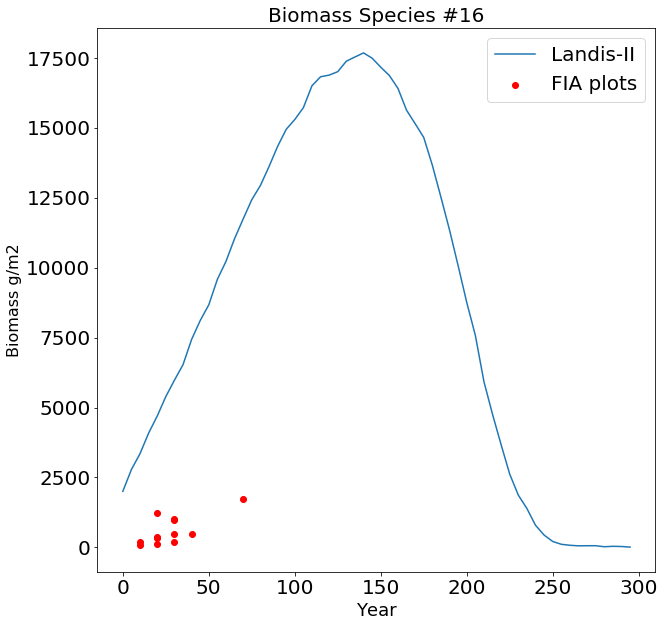

Fraser fir

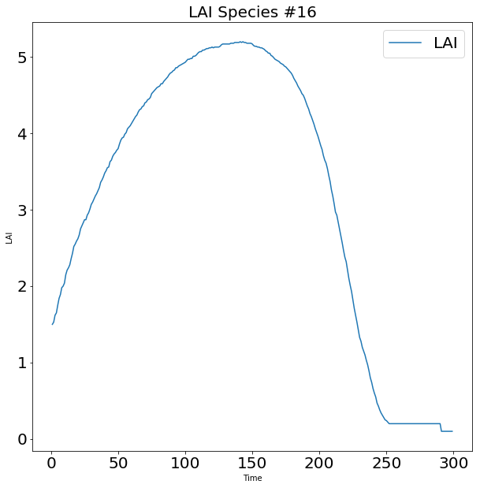

Fraser fir

Published Fir-Spruce stand LAI He, L., Chen, J. M., Pan, Y., Birdsey, R., & Kattge, J. (2012). Relationships between net primary productivity and forest stand age in US forests. Global Biogeochemical Cycles, 26(3).

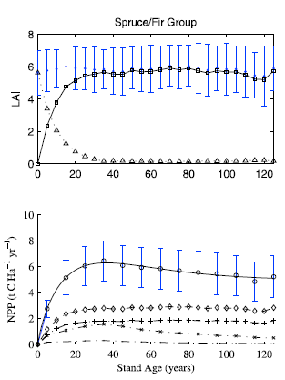

FF LAI